# Replication Analysis of Mattingly (2017)

刘世禹

2019/2/20

## 介绍

本文是对于Mattingly (2017) 的复制性研究，文章原题目为“Colonial legacies and state institutions in China: evidence from a natural experiment.” 首次发表于Comparative Political Studies杂志2015年第一期，并在2017年第4期作为中国政治研究专题收录。其文主要以自然实验的方法，研究早期国家能力建设可能存在的长期影响。作者通过地理断点回归的设计，比较那些在日据时期，位于伪满洲国西部边界两侧——即那些处在当时官僚体系建设方面相对有效的伪满洲国政权直接控制下，与处在其西侧由蒙古旧王公凭借日本支持而成立的半自治性质的伪蒙疆联合自治政府控制下、行政管理体制相对松散的乡镇，发现二者在日后的教育和医疗水平、经济发展以及行政密度等方面均存在显著差异。据此，作者得出结论，认为早期国家能力建设相对投入多少是导致这些差异的主要原因。

而本文则使用作者提供的原始数据，重新进行独立分析，以试图验证上述结论的可靠性。研究遵循复制性研究 (replication) 的一般流程。具体来说，本文首先按照作者在文章中描述的方法，复现其主要结果。并进一步，使用近年来来针对地理断点回归更精细的计量方法，发现作者在其部分结论的可靠性可能存在一些问题。

写作结构上参考其他复制性研究写作思路，包含了大部分原始代码和对应的文字解释，以及为了清晰性，所有结果也和原作者一样均以图示而非表格的形式呈现。

## 数据、方法和分析过程

### 数据来源

即作者提供的原始数据，其中地理数据为伪满州国的历史边界和2000年现今区县级行政区边界的shp文件，乡镇层级数据则来自添加了地理编码的2000年第五次人口普查数据。

```r
dt <- read_csv("township_data.csv"); dt
```

| X1 | treat | forcing | border_longitude | border_latitude | light_stable | soil | slope_srtm | yearly_pre | han_pct | monglian_pct | mining | government_pct | improved_sanitation_pct | above_primary | non_agricultural | higher_income | point_x | point_y |
| --- | --- | --- | --- | --- | --- | --- | --- | --- | --- | --- | --- | --- | --- | --- | --- | --- | --- | --- |
| 1 | 0 | -197.3904201 | 115.9397 | 41.55707 | 0 | 3 | 0.653907 | 277 | 0.397145669 | 0.602854331 | 0 | 0.031007752 | 0.000000000 | 0.1043307087 | 0.06976744 | 0.19642857 | 114.6545 | 42.78300 |
| 2 | 0 | -180.6144699 | 115.9397 | 41.55707 | 0 | 2 | 0.469639 | 285 | 0.345195730 | 0.631079478 | 0 | 0.000000000 | 0.000000000 | 0.0201660735 | 0.01694915 | 0.23404255 | 114.8128 | 42.72806 |
| 3 | 0 | -138.7097133 | 115.9397 | 41.55707 | 0 | 1 | 1.165060 | 322 | 0.993173692 | 0.005526059 | 0 | 0.005000000 | 0.003278689 | 0.1423772890 | 0.08166667 | 0.09215017 | 114.8716 | 42.20287 |
| 4 | 0 | -163.1974883 | 115.9397 | 41.55707 | 0 | 1 | 0.224344 | 296 | 0.269172169 | 0.723717623 | 0 | 0.017543860 | 0.000000000 | 0.0858303707 | 0.09649123 | 0.35087719 | 114.8881 | 42.58205 |
| 5 | 0 | -151.1694821 | 115.9397 | 41.55707 | 0 | 1 | 2.477340 | 317 | 0.537744641 | 0.452003728 | 0 | 0.004587156 | 0.000000000 | 0.1363777571 | 0.01834862 | 0.17204301 | 114.9117 | 42.44781 |
| 6 | 0 | -190.0780173 | 116.4847 | 43.24796 | 8 | 1 | 0.599352 | 247 | 0.202923977 | 0.792397661 | 0 | 0.000000000 | 0.000000000 | -0.0023391813 | 0.00000000 | 0.28846154 | 114.9613 | 44.02540 |
| 7 | 0 | -189.4228717 | 116.4847 | 43.24796 | 7 | 1 | 0.220040 | 246 | 0.652178035 | 0.320045504 | 6 | 0.170118343 | 0.051696284 | 0.2485187467 | 0.92011834 | 0.48770492 | 114.9642 | 44.01822 |
| 8 | 0 | -115.7102689 | 115.9397 | 41.55707 | 0 | 1 | 0.603030 | 352 | 0.985323360 | 0.011362560 | 0 | 0.000000000 | 0.000000000 | 0.0971498911 | 0.04441261 | 0.18892508 | 114.9787 | 41.95785 |
| 9 | 0 | -125.1032452 | 115.9397 | 41.55707 | 0 | 1 | 0.257352 | 331 | 0.990687437 | 0.007788689 | 0 | 0.000000000 | 0.005050505 | 0.1997968168 | 0.06896552 | 0.07291667 | 114.9894 | 42.16048 |
| 10 | 0 | -133.7700600 | 115.9397 | 41.55707 | 8 | 1 | 0.437621 | 329 | 0.725879818 | 0.255027532 | 2 | 0.180967239 | 0.005825243 | 0.3139214747 | 0.92667707 | 0.55530474 | 114.9979 | 42.30662 |

[output cut: 608 more lines]

### 研究设计和方法

#### 历史上伪满洲国的西部边界

原研究之所以选择伪满洲国的西部边界而非其他（比如南部）边界的原因，在于为了达到自然实验的效果，需要保持其他不可观测因素尽可能的相似性。

在历史上，满洲国南部边界的确立基本沿袭了明清以来传统的山海关长城一线，边界两侧在地理、气候条件和民族构成上可能本身即存在差异。并且在1935年后，随着日军进一步推进其侵华战略，其南部的热河、河北等地先后策动了“五省自治”和多个伪政权的建立，此后政权更迭、战争进程和中共游击队等的活动也均可能构成影响区域发展水平的混淆因素。而在伪满洲国的西部边境，直到1945年苏联对日宣战，无论在两侧的伪满政权还是蒙疆政权境内，基本都没有大规模的冲突发生；且西部边境本身的确立并非完全依照民族或历史原则，如在伪满洲国辖区西部的呼伦贝尔、哲里木、昭乌达三盟人口构成上以蒙古族为主地区的归属上，双方还始终存在一些争议。因此，相比之下，选取伪满洲国的西部边境从理论上来说可以避免明显的混淆性因素。当然，是否还有其他可能的混淆因素存在还需要如下面提到的使用统计方法来检验。

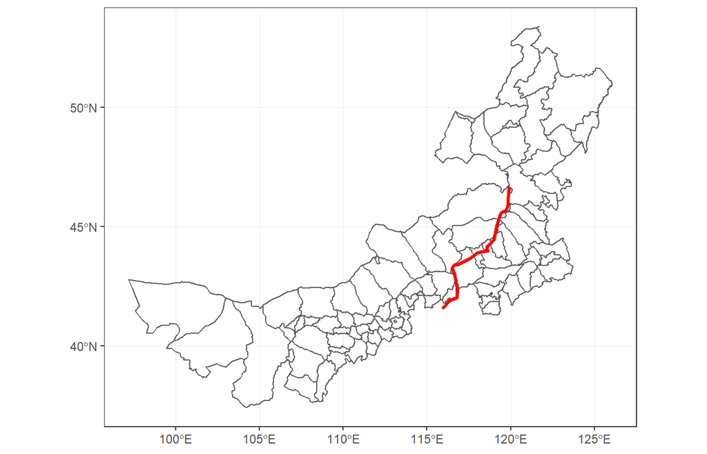

```r
china <- read_rds("C:/Users/liushiyu1223/Downloads/gadm36_CHN_3_sf.rds")

map1_2 <- china %>%
  filter(NAME_1 == "Nei Mongol") %>%
  ggplot()+
  geom_sf(fill = "white", alpha = .1)+
  geom_sf(data = manchukuo, colour = "red", size = 1.2)+
  theme_bw()

map1_2
```

#### 以地理边界做断点回归

此种方法的核心观点在于：当某一政策或更更广义的“干预”只在某一地区内部实行，而在其临近的地区并未推行，那么如果两地之间的地理或行政边界本身的确定与此项政策无关，那么对于那么生活在边界附近、其他各方面条件都相对接近的研究对象来说，是否受到此项政策的影响可被视为是近似于随机分配的，而两组对象此后表现出的譬如在发展水平上呈现出差异，即可以认为是此项政策导致的。

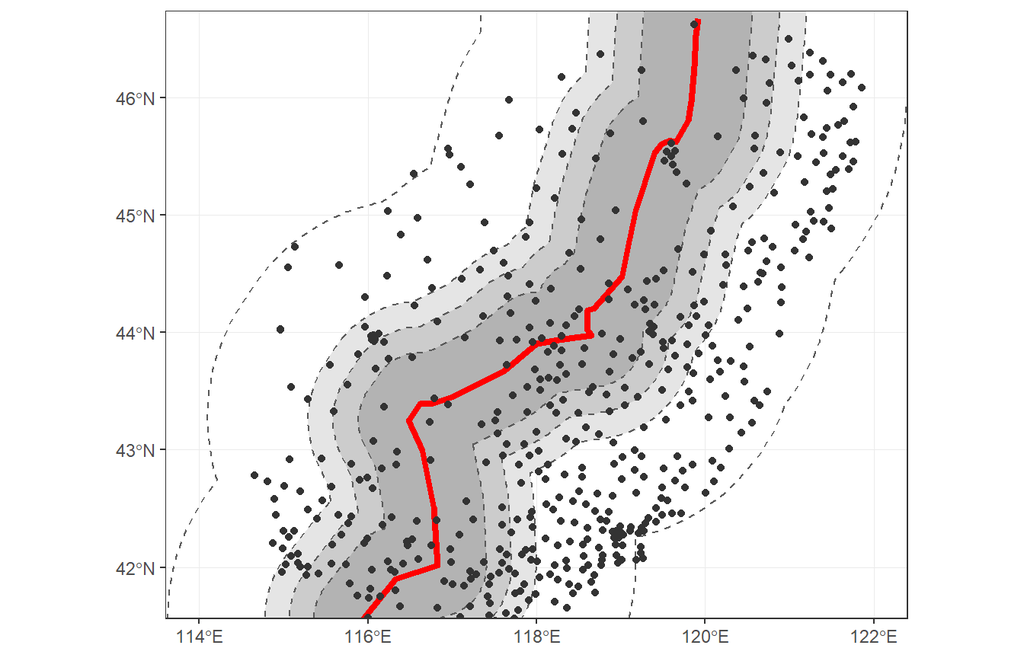

```r
dt_sf <- st_as_sf(dt, coords = c("point_x", "point_y"), crs = 4326)

manchukuo0 <- manchukuo %>% st_transform(21463)

boundary_buff_50km <- st_buffer(manchukuo0, dist = 50000) %>% st_transform(4326)
boundary_buff_75km <- st_buffer(manchukuo0, dist = 75000) %>% st_transform(4326)
boundary_buff_100km <- st_buffer(manchukuo0, dist = 100000) %>% st_transform(4326)
boundary_buff_200km <- st_buffer(manchukuo0, dist = 200000) %>% st_transform(4326)

map2 <- ggplot()+
  geom_sf(data = boundary_buff_200km, fill = "white", linetype = "dashed", alpha = .1)+
  geom_sf(data = boundary_buff_100km, fill = "grey90", linetype = "dashed")+
  geom_sf(data = boundary_buff_75km, fill = "grey80", linetype = "dashed")+
  geom_sf(data = boundary_buff_50km, fill = "grey70", linetype = "dashed")+
  geom_sf(data = manchukuo, colour = "red", size = 1.5)+
  geom_sf(data = dt_sf, color = "grey20")+
  coord_sf(xlim = c(114, 122), ylim = c(41.8, 46.5))+
  labs(x = NULL, y = NULL, fill = "Elevation")+
  scale_fill_gradient(low = "white", high = "black")+
  theme_bw()

map2
```

#### 断点回归的一般流程

地理（边界）断点回归属于断点回归的一个特例，但遵循断点回归实施的基本相同的流程，其均可大致分为以下的五个步骤，参见 Lee & Lemieux (2010); Skovron & Titiunik (2015)

1. McCrary检验：即检验分配变量（forcing variable）在统计分布上是否存在跳跃，以避免可能的选择效应或人为的数据操纵。而在地理断点回归中通常无需此步，因为其分配变量是地理距离，不存在上述问题。
2. 平衡性检验，即检验（边界两侧）控制组和对照组在其他可能的影响因素上是否存在差异。以满足两组在结果变量上的差异的原因只是是否受到干预，而非其他可能方面差异的影响。
3. 带宽选择，确定究竟距离边界多远距离内的研究对象（这里是乡镇）会被认为是我们需要关注的，从而进入样本并分析。在其选择上以前一般按照经验法则或前人文献，以及选取如25km、50km、75km这样的多个距离以检验结果的文件。不过随着今年理论计量学者的研究，这一在决定断点回归效果和可信程度上至关重要的问题已经基本使用交叉验证等方法自动而非人工的进行选择。
4. 选择具体模型，进行分析并得到回归结果。
5. 安慰剂检验，为避免关注的结果变量只是纯粹偶然地在某一特定值或地理边界处发生了跳跃，在进行完基本的分析之后通常还会进行所谓安慰剂检验（Placebo Test），通过在与真实边界的不同距离上人为构造出“虚拟”的边界，即改变原本的处理条件，重复上一步的分析过程，看是否还能得出显著的结论，如果是，则很可能研究所捕捉到的其实为并不真实存在的“处理效应”。

#### 平衡性检验 —— 协变量

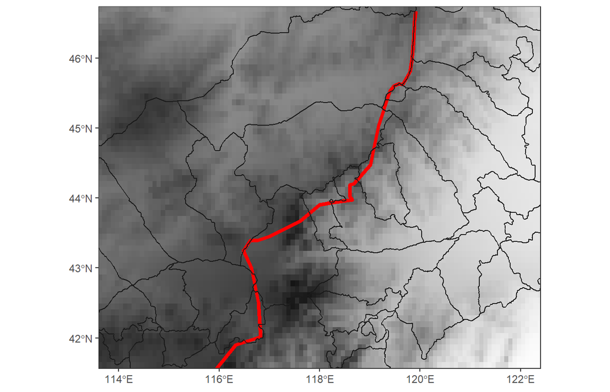

```r
map3 <- ggplot()+
  geom_raster(data = alt1, aes(x = x, y = y, fill = GloElev_5min))+
  geom_sf(data = manchukuo, colour = "red", size = 1.5)+
  geom_sf(data = cline, color = "grey10")+
  coord_sf(xlim = c(114, 122), ylim = c(41.8, 46.5))+
  labs(x = NULL, y = NULL, fill = "Elevation")+
  scale_fill_gradient(low = "white", high = "black")+
  theme_bw()+
  theme(legend.position = "none")

map3
```

这里按照作者的方案分别检测了边界两侧乡镇在自然地理条件，如地表坡度、降水、土壤、矿产资源上的差异。与一般研究先选取完一个或几个特定带宽再进行检验不同，此处实际上每隔一公里，检验了距100公里范围内所有可能的带宽设定下，两侧在上述方面可能存在的差异，并通过图示如下。

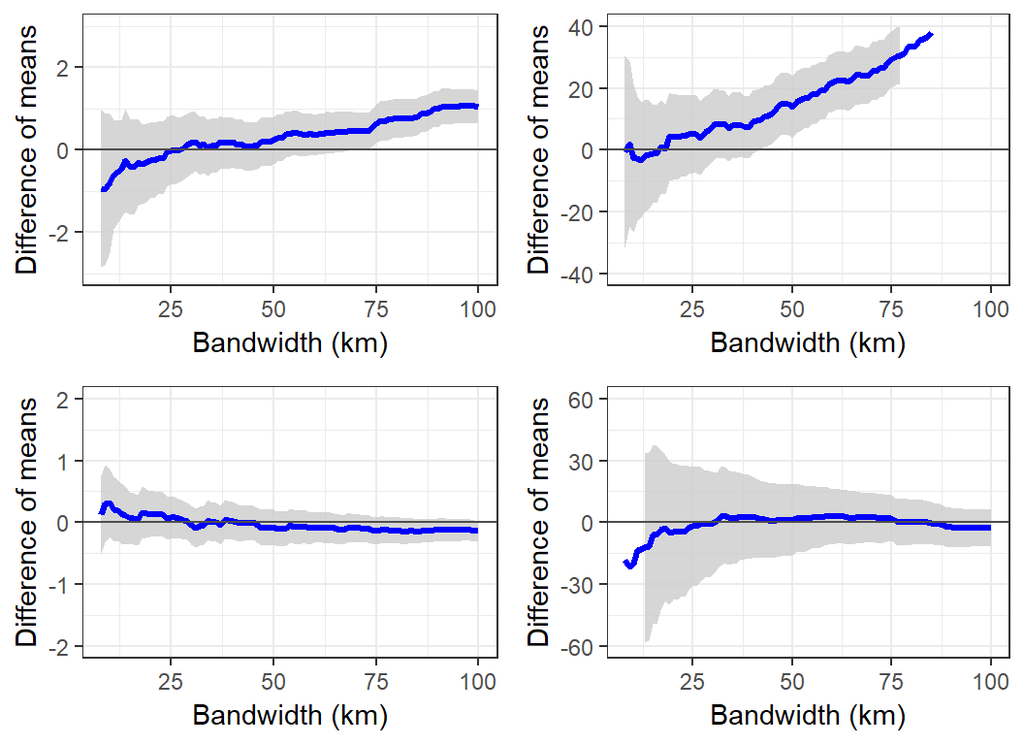

```r
# Balance Test

balance_plot <- function(dt, var) {

  var = enquo(var)
  sequence=seq(8, 100, 1)
  conf_int1 = rep(NA, length(sequence))
  conf_int2 = rep(NA, length(sequence))
  estimate = rep(NA, length(sequence))

  for(i in 1:length(sequence)){
    data_in_band <- dt %>% filter(forcing > -sequence[i] & forcing < sequence[i])
    t = t.test(pull(filter(data_in_band, treat == 1), !!var), pull(filter(data_in_band, treat == 0), !!var))
    conf_int1[i] = t$conf.int[1]
    conf_int2[i] = t$conf.int[2]
    estimate[i] = t$estimate[1] - t$estimate[2]
    data = tibble(sequence, conf_int1, conf_int2, estimate)
  }

  ggplot(data)+
    geom_ribbon(aes(sequence, ymax = conf_int1, ymin = conf_int2), fill = "grey80", alpha = .8)+
    geom_line(aes(sequence, estimate), colour = "blue", size = 1.2)+
    geom_hline(yintercept = 0, colour = "grey30")+
    expand_limits(x = c(10, 100))+
    xlab("Bandwidth (km)")+
    ylab("Difference of means")+
    theme_bw()
}
```

可以看到在大部分的带宽选择下，除了降水量一项上，在距边界50公里以上两侧开始呈现出明显的差异，其他方面两侧的条件基本相近。

#### 平衡性检验 —— 结果变量

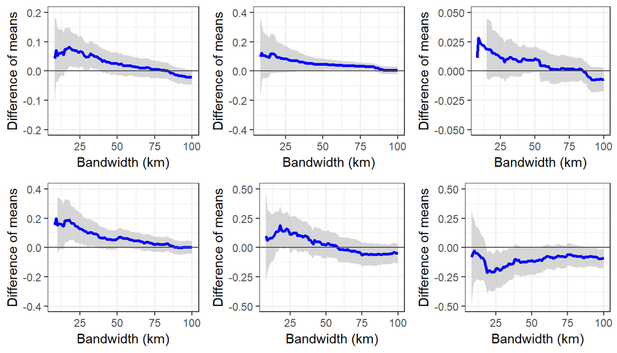

### 回归模型

在完成上述平衡性检验后，则开始使用更为严格的回归模型对关注的几个结果变量进行分析

#### 1.1 RDD模型

首先是作者在原文中采用的Naive RDD模型，按照如开始时介绍的逻辑，假设在边界附近足够小的一段距离内，经过前面的平衡性检验两侧样本在各方面都十分相似，而研究对象是否受到政策影响完全取决于其处于地理边界的哪一侧，那么如果使用同样的模型形式分别对两侧样本分别做回归，则两侧拟合后模型在截距上的差异，则可被认为是对所谓政策效应的识别。 ，其具体形式如下

$$y_i=\alpha+\beta_1c+\beta_2z_i + \beta_3z_ic+\varepsilon$$

- 其中$c$为是否受处理的指示变量，$\beta$即估计的处理效应
- 由$z_i$为该乡镇到边界的距离

#### 1.2 RDD结果

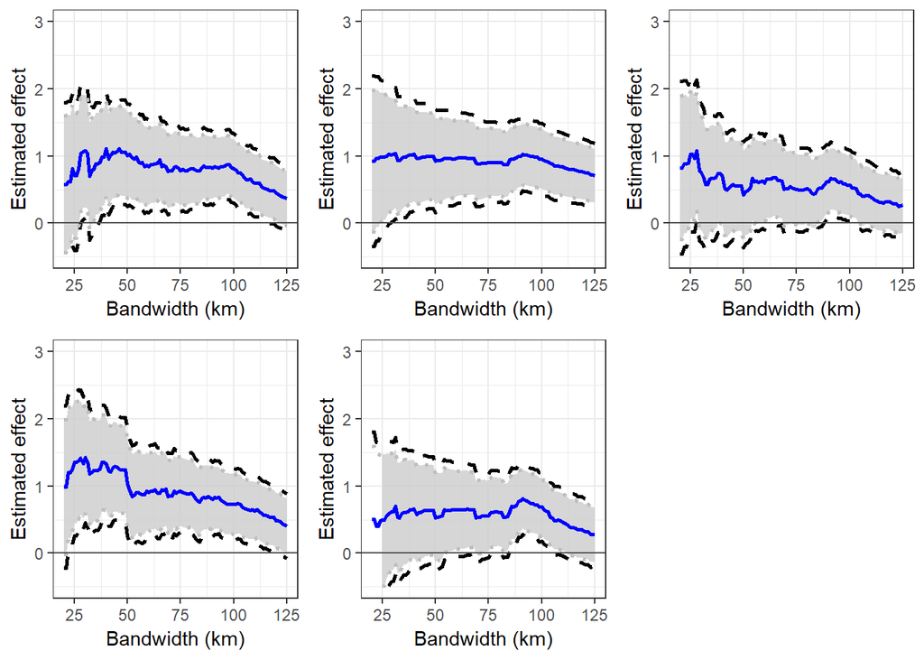

```r
# RDD
reg_plot <- function(dt, var) {

  sequence=seq(15, 150, 1)
  conf_int1 = rep(NA, length(sequence))
  conf_int2 = rep(NA, length(sequence))
  conf_int3 = rep(NA, length(sequence))
  conf_int4 = rep(NA, length(sequence))
  coef1 = rep(NA, length(sequence))

  for(i in 1:length(sequence)){
    data_in_band <- dt %>% filter(forcing > -sequence[i] & forcing < sequence[i])
    model1<-lm(paste("scale(" , var, ") ~ treat + forcing + treat*forcing"), data = data_in_band)
    conf_int1[i] = confint(model1)[2,1]
    conf_int2[i] = confint(model1)[2,2]
    conf_int3[i] = confint(model1, level=0.90)[2,1]
    conf_int4[i] = confint(model1, level=0.90)[2,2]
    coef1[i] = coef(model1)[2]
    data = tibble(sequence, conf_int1, conf_int2, conf_int3, conf_int4, coef1)
  }
  ggplot(data)+
    geom_ribbon(aes(sequence, ymax = conf_int3, ymin = conf_int4), fill = "grey80", alpha = .8)+
    geom_line(aes(sequence, coef1), colour = "blue", size = 1)+
    geom_line(aes(sequence, conf_int1), linetype = "dashed", size = 1)+
    geom_line(aes(sequence, conf_int2), linetype = "dashed", size = 1)+
    geom_line(aes(sequence, conf_int3), linetype = "dotted", colour = "grey", size = 1)+
    geom_line(aes(sequence, conf_int4), linetype = "dotted", colour = "grey", size = 1)+
    geom_hline(yintercept = 0, colour = "grey30")+
    xlim(c(20, 125))+
    ylim(c(-0.5, 3))+
    xlab("Bandwidth (km)")+
    ylab("Estimated effect")+
    theme_bw()
}
```

以上结果显示出，在大部分带宽选择下，曾经处于伪满洲国辖区内，对于当地的教育和医疗水平，以及由统计所得的人均收入水平有明显的影响。

#### 2.1 GRD模型

GRD最早由Dell (2010)使用, 较详细的方法论指南Keele & Titiunik (2014)，其核心逻辑上述RDD模型相同，但相比单纯以到边界的距离为分配变量，GRD方法还考虑了即使到边界距离相同但处在不同方位处对象的异质性，进而使用两个维度的经纬度坐标及其到边境最近点的距离为分配变量进行回归

$$y_i=\alpha+\beta c_i+\omega X_i+\gamma Z_i+\phi W_i+\varepsilon$$

- 其中$c_i$为是否受处理的指示变量，$\beta$即估计的处理效应
- $X_i$为协变量
- $Z_i$是该乡镇的地理坐标点及其二次项
- $phi$为距该地最近边界的地理坐标

#### 2.2 GRD结果

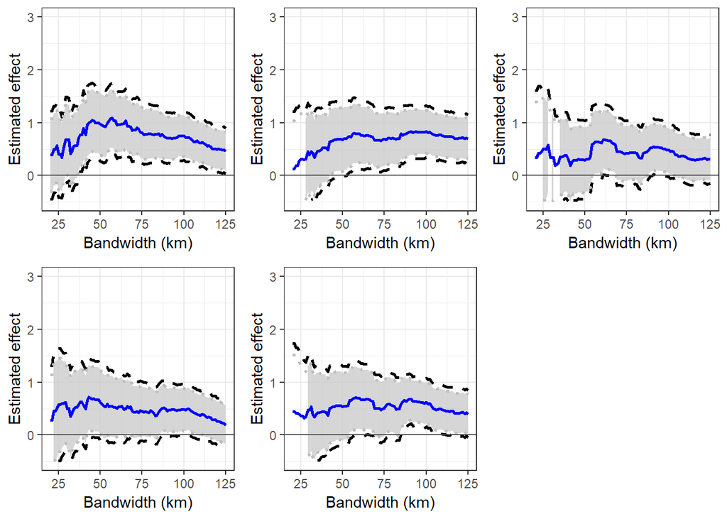

```r
# GRD
dt <- dt %>%
  mutate(point_x_2 = point_x^2,
         point_y_2 = point_y^2,
         point_x_y = point_x * point_y,
         point_x_3 = point_x^3,
         point_y_3 = point_y^3,
         point_x_2_y = point_x_2 * point_y,
         point_x_y_2 = point_x * point_y_2)

reg_plot2 <- function(dt, var) {

  sequence=seq(15, 150, 1)
  conf_int1 = rep(NA, length(sequence))
  conf_int2 = rep(NA, length(sequence))
  conf_int3 = rep(NA, length(sequence))
  conf_int4 = rep(NA, length(sequence))
  coef1 = rep(NA, length(sequence))

  for(i in 1:length(sequence)){
    data_in_band <- dt %>% filter(forcing > -sequence[i] & forcing < sequence[i])
    model2 <- lm(paste("scale(" , var, ") ~ treat + point_x + point_y + point_x_2 + point_y_2 + point_x_y + han_pct + monglian_pct + border_longitude + border_latitude"),
               data = data_in_band)
    conf_int1[i] = confint(model2)[2,1]
    conf_int2[i] = confint(model2)[2,2]
    conf_int3[i] = confint(model2, level=0.90)[2,1]
    conf_int4[i] = confint(model2, level=0.90)[2,2]
    coef1[i] = coef(model2)[2]
    data = tibble(sequence, conf_int1, conf_int2, conf_int3, conf_int4, coef1)
  }
  ggplot(data)+
    geom_ribbon(aes(sequence, ymax = conf_int3, ymin = conf_int4), fill = "grey80", alpha = .8)+
    geom_line(aes(sequence, coef1), colour = "blue", size = 1)+
    geom_line(aes(sequence, conf_int1), linetype = "dashed", size = 1)+
    geom_line(aes(sequence, conf_int2), linetype = "dashed", size = 1)+
    geom_line(aes(sequence, conf_int3), linetype = "dotted", colour = "grey", size = 1)+
    geom_line(aes(sequence, conf_int4), linetype = "dotted", colour = "grey", size = 1)+
    geom_hline(yintercept = 0, colour = "grey30")+
    xlim(c(20, 125))+
    ylim(c(-0.5, 3))+
    xlab("Bandwidth (km)")+
    ylab("Estimated effect")+
    theme_bw()
}
```

以上结果显示出，当使用更严格的GRD方法时，在大部分带宽选择下，曾经处于伪满洲国辖区内，对于当地的教育和医疗水平有明显的影响，而之前的人均收入水平这一项则变得不再显著。

#### 2.2 GRD结果的图示

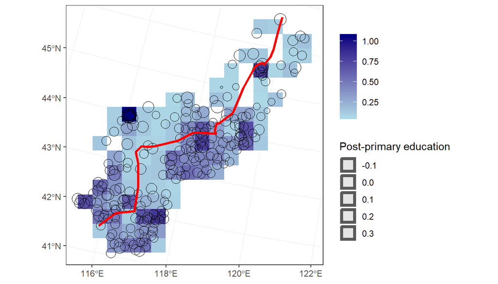

```r
dt_sf_pro = dt %>%
  filter(forcing >= -100 & forcing <= 100) %>%
  add_predictions(lm(above_primary ~ treat + point_x + point_y + point_x_2 + point_y_2 + point_x_y + han_pct + monglian_pct + border_longitude + border_latitude, dt)) %>%
  st_as_sf(coords = c("point_x", "point_y"), crs = 4326) %>%
  st_transform(21463)

raster_template = raster(extent(dt_sf_pro), resolution = 35000,
                         crs = st_crs(dt_sf_pro)$proj4string)

dt_raster = as.data.frame(rasterize(dt_sf_pro, raster_template, field = "pred", fun = "sum"), xy = T)

ggplot()+
  geom_raster(data = dt_raster, aes(x = x, y = y, fill = layer))+
  geom_sf(data = dt_sf_pro %>% st_transform(21463), aes(size = above_primary), shape = 1)+
  geom_sf(data = manchukuo %>% st_transform(21463), colour = "red", size = 1.2)+
  theme_bw()+
  scale_fill_continuous(low = "light blue", high = "navy",
                       guide="colorbar", na.value = NA)+
  labs(x = NULL, y = NULL, fill = NULL, size = "Post-primary education")
```

## 对作者模型的改进

以上为对作者原本的研究设计进行复现，而随着理论计量学者对断点回归、以及地理断点回归方法的进一步讨论，更为精细的方法被发明和使用，尤其在对于其核心假设的检验和模型具体形式的选择上，实际还是存在许多并没有为原作者所使用的新进展。尤其是目前主流的方法通常已经不需像作者一样去算出所有带宽下的回归系数，而可以使用交叉验证的方法直接计算最优的带宽并在此基础上进行分析。

断点回归方法的新进展

- 带宽选择（CV, IK, CCT）Imbens & Kalyanaraman (2012); Calonico, Cattaneo & Titiunik (2014a)
- 多项式模型阶数选择（local polynomial）Gelman & Imbens (2014)
- 权重选择（kernel）
- 标准误修正 Calonico, Cattaneo & Titiunik (2014a)

而由Titiunik等开发的`rdrobust`包，则包含了上述近年来断点回归理论发展的具体实现

```r
rdrobust(y = dt$above_primary, x = dt$forcing)
```

```
## Call: rdrobust
##
## Number of Obs.                  618
## BW type                       mserd
## Kernel                   Triangular
## VCE method                       NN
##
## Number of Obs.                 146         472
## Eff. Number of Obs.             65          95
## Order est. (p)                   1           1
## Order bias  (p)                  2           2
## BW est. (h)                 75.458      75.458
## BW bias (b)                120.604     120.604
## rho (h/b)                    0.626       0.626
```

参照以上新进展，本文对作者的基本模型进行了修正，具体包含以下几个方面

#### 修正后模型结果

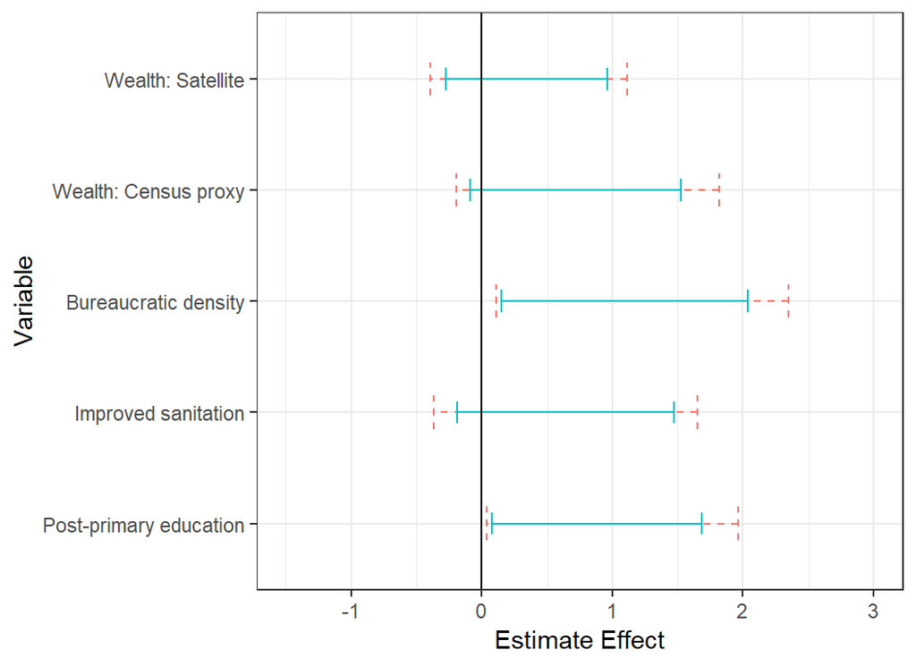

```r
# robustRD
temp1 <- c("above_primary", "improved_sanitation_pct", "government_pct", "higher_income", "light_stable")

rd <- function(var){
  coef = rep(NA, length(var))
  rcoef = rep(NA, length(var))
  ci_l = rep(NA, length(var))
  ci_r = rep(NA, length(var))
  rci_l = rep(NA, length(var))
  rci_r = rep(NA, length(var))

  for (i in 1:length(var)){
    temp2 <- temp1[i]
    temp3 <- dt[[temp2]]
    r <- rdrobust(y = scale(temp3), x = dt$forcing)
    variable = temp1
    coef[i] = r$coef[1]
    rcoef[i] = r$coef[3]
    ci_l[i] = r$ci[1,1]
    ci_r[i] = r$ci[1,2]
    rci_l[i] = r$ci[3,1]
    rci_r[i] = r$ci[3,2]
    }
  data = tibble(variable, coef, rcoef, ci_l, ci_r, rci_l, rci_r)
}

data = rd(temp1)

ggplot(data, aes(y= variable, x = coef))+
  geom_errorbarh(aes(xmin = rci_l, xmax = rci_r), colour = scales::hue_pal()(4)[1], height = .3, linetype = "dashed")+
  geom_errorbarh(aes(xmin = ci_l, xmax = ci_r), colour = scales::hue_pal()(4)[3], height = .2)+
  geom_vline(xintercept = 0)+
  xlab("Estimate Effect")+
  ylab("Variable")+
  xlim(-1.5, 3)+
  scale_y_discrete(labels = c("Post-primary education", "Improved sanitation", "Bureaucratic density", "Wealth: Census proxy", "Wealth: Satellite"))+
  theme_bw()
```

#### 安慰剂检验

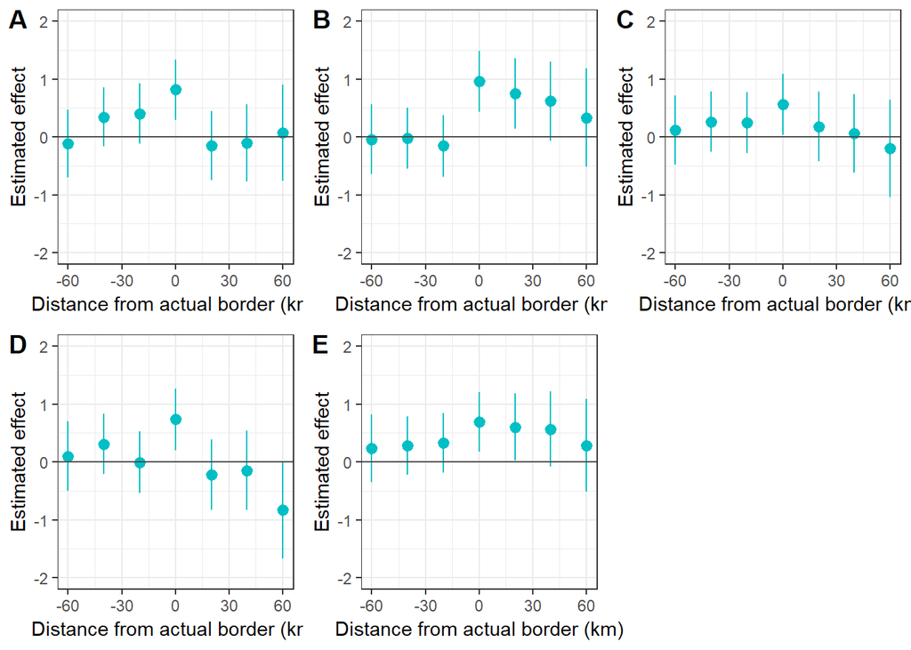

```r
# Placebo Test

placebo_plot2 <- function(dt, var) {

  placebo_data <- dt %>% filter(forcing > -100 & forcing < 100)

  sequence = seq(-60, 60, 20)
  p_value = rep(NA, length(sequence))
  coef1 = rep(NA, length(sequence))
  conf_int1 = rep(NA, length(sequence))
  conf_int2 = rep(NA, length(sequence))

  for(i in 1:length(sequence)){
    placebo_data <- placebo_data %>%
      mutate(forcing2 = forcing + sequence[i],
             treat2 = if_else(forcing2 > 0, 1, 0 ))

    model3 <- lm(paste("scale(" , var, ") ~ treat2 + forcing2 + treat2*forcing2"), data = placebo_data)

    p_value[i] = coef(summary(model3))[2, 4]
    coef1[i] = coef(summary(model3))[2]
    conf_int1[i] = confint(model3)[2,1]
    conf_int2[i] = confint(model3)[2,2]
    data = tibble(sequence, coef1, conf_int1, conf_int2)
    }

    ggplot(data, aes(sequence, coef1))+
      geom_pointrange(aes(ymin = conf_int1, ymax = conf_int2), colour = scales::hue_pal()(4)[3])+
      geom_hline(yintercept = 0, colour = "grey30")+
      xlim(c(-60, 60))+
      ylim(c(-2, 2))+
      xlab("Distance from actual border (km)")+
      ylab("Estimated effect")+
      theme_bw()
}
```

#### 附加检验（使用县级数据）

而在上述基础上基于单一年度截面讨论的基础上，还有必要考虑到时间上的混淆因素，探求所谓伪满洲国边界-国家能力建设的效果是否可能实际上是建国以来其他的运动或举措导致的。但由于数据可得性的问题，个体或基层层面涉及如此长时段的面板数据并不存在。作者使用的一种退而求其次的方案是在县级层面来直接观察和比较（主体部分）位于边界两侧区县主要结果变量的时序变化。如下图所示：

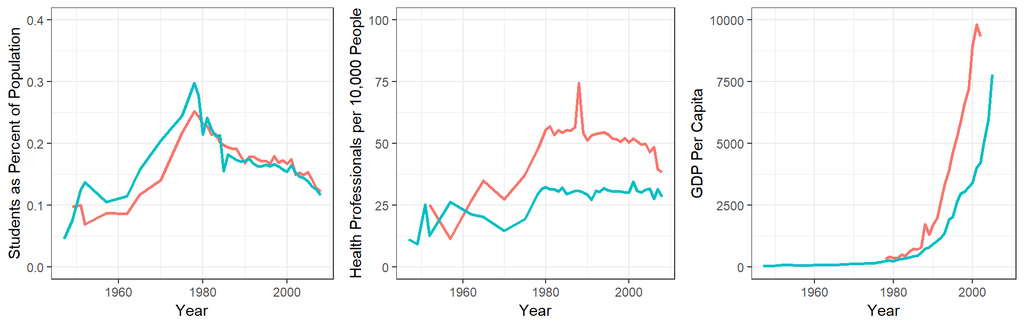

可以看到

- 总体上，从县一级来看，曾经位于伪满洲国辖区内的区县在1980年代之前确实在教育水平上高于临近非伪满洲国辖下区县，而在80年代后二者间的差距即开始变得不明显，但这不能动摇在更细致的乡镇一级的结果。
- 但与之前结论不同的是，在医疗卫生水平和经济发展水平上，则反而是处于非伪满洲国的区县呈现出了更高的发展水平。尤其在大多数的理论和实证结果中，都认为经济发展和教育水平之间具有明显的正向关系，则剩下比较可能的解释是非伪满州国地区在1980年后的经济增长是导致两地之间教育水平差距缩小的主要原因。
- 尽管如此，单纯利用县级的时序数据，还是不能完全排除建国后其他建在因素对教育水平的可能影响。

## 总结和讨论

正如Gary King (1995) 所说：“能完全理解和评估一个经验研究好坏与否的唯一途径是弄清楚数据生成和分析实施的整个过程”。这或许也是复制性研究最主要的意义所在。